# Week 2. Introduction to R (III)

분류형 변수의 서로 다른 수준 간의 차이를 보여주는 데에는 직접 플롯에 `color`나 `size`를 조정하는 것 말고도 `facets`을 이용하는 방법도 있습니다. `facet_wrap()`이나 `facet_grid()`를 사용할 수 있는데, `facet_wrap()`이 조금 더 유용합니다.

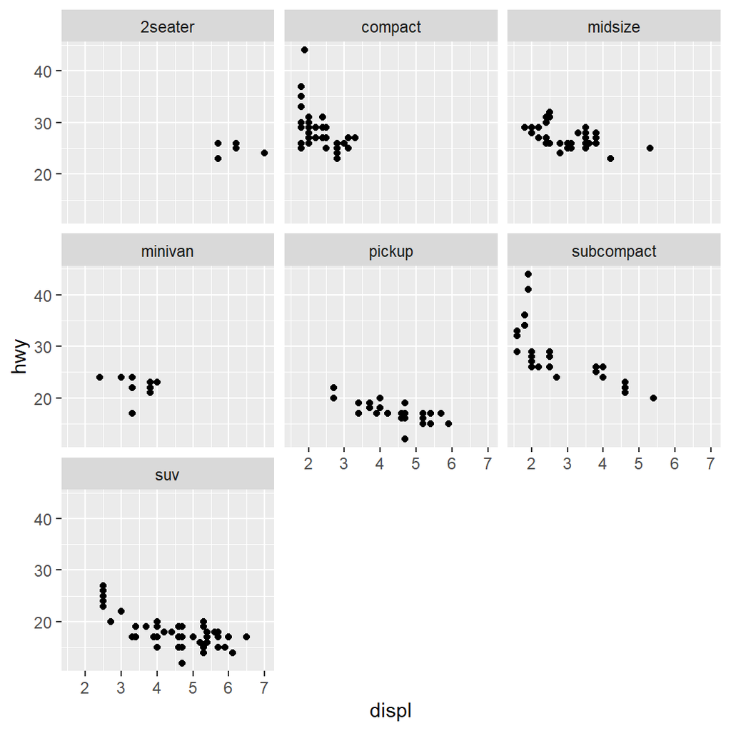

```r
ggplot(mpg, aes(displ, hwy)) +
  geom_point() +
  facet_wrap(~ class)
```

`ggplot` 플롯에 더할 수 있는 다양한 유형의 `geom_*` 함수들로는, `geom_point()`, `geom_bar()` (또는 `geom_col()`), `geom_path()` (또는 `geom_line()`), 부드러운 맞춤 선을 그려주는 `geom_smooth()`, 그리고 `geom_boxplot()` 등이 있습니다.

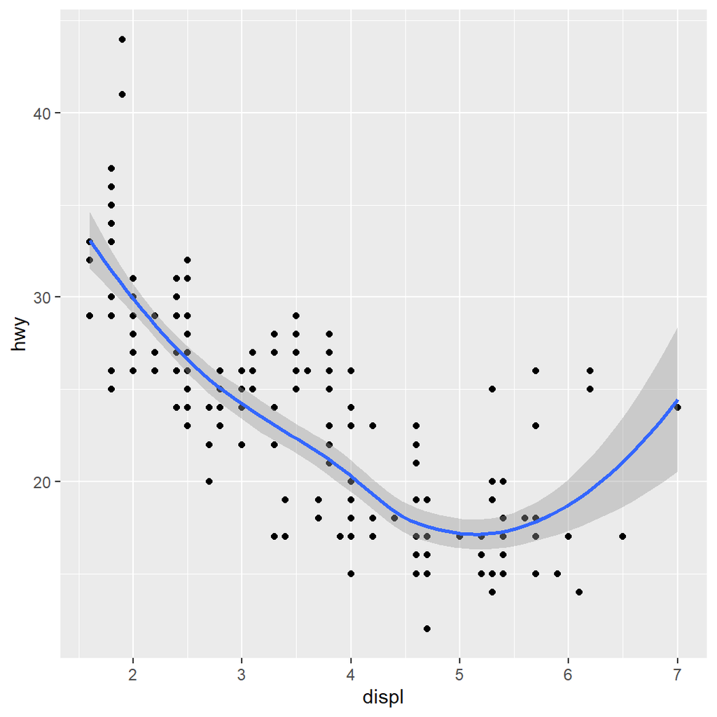

```r
ggplot(mpg, aes(displ, hwy)) +
  geom_point() +
  geom_smooth() # 자동으로 국소가중선형회귀(Locally Weighted Scatterplot Smoother, LOWESS) 곡선을 추정해서 그려줍니다.
```

선형 모델을 그리는 데에도 사용할 수 있습니다.

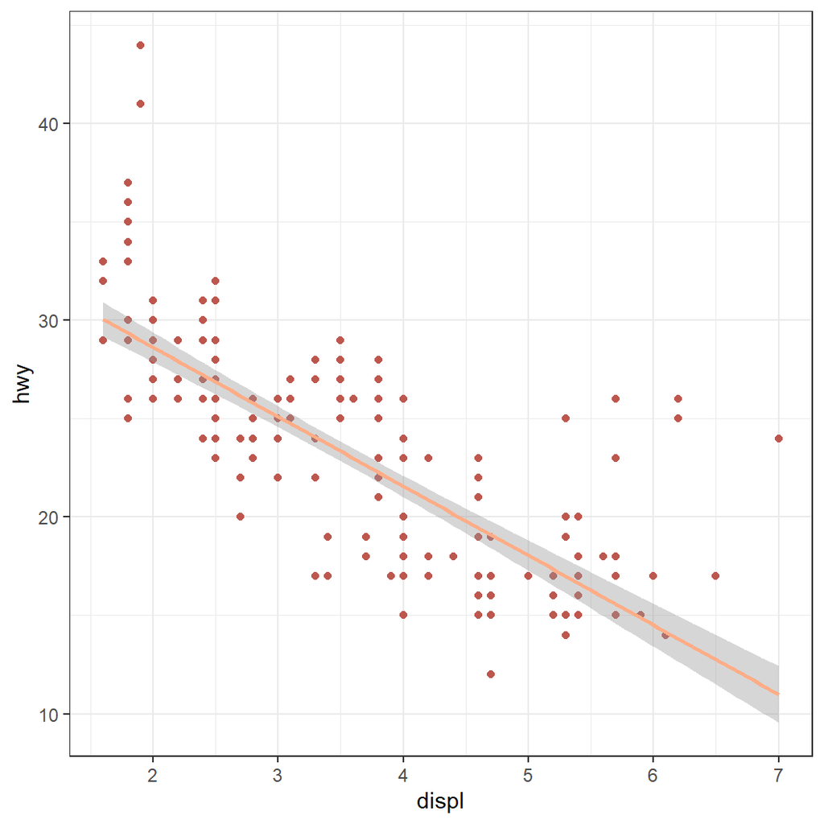

```r
lm_plot <- ggplot(mpg, aes(displ, hwy)) +
  geom_point(color = "#bd574e") +
  geom_smooth(method = 'lm', color = "#ffad87") +
  theme_bw()
lm_plot # 위의 컬러코드에 대해서는 다음을 참고하세요: colorhunt.co
```

이게 익숙해지면 제곱항과 같이 자신의 함수를 다양하게 구성해서 `ggplot` 함수에 투입, 플롯으로 나타낼 수 있습니다.

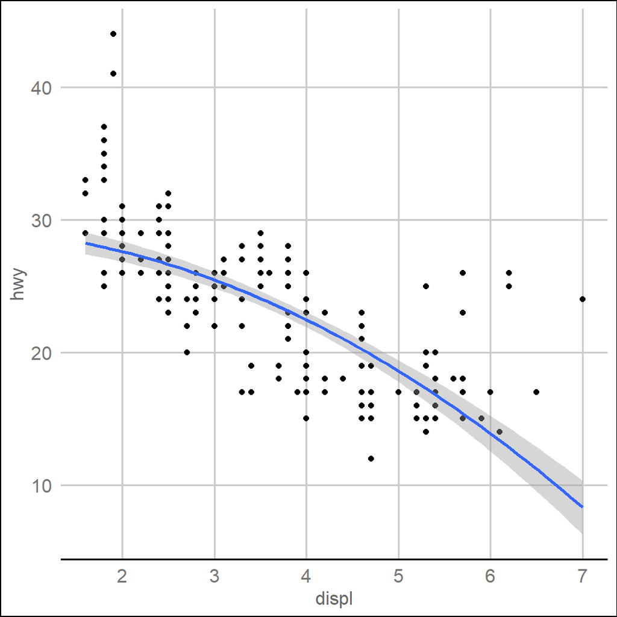

```r
## 함수를 직접 투입해보겠습니다.
ggplot(mpg, aes(displ, hwy)) +
  geom_point() +
  geom_smooth(method = "lm", formula = y ~ I(x^2)) +
  ggthemes::theme_gdocs() ## ggthemes 패키지는 다양한 테마를 제공합니다.
```

`MASS` 패키지 등을 이용하여 이탈치(outliers)의 영향을 받지 않는 로버스트 선형모델을 사용하여 플롯으로 보여줄 수 있습니다.

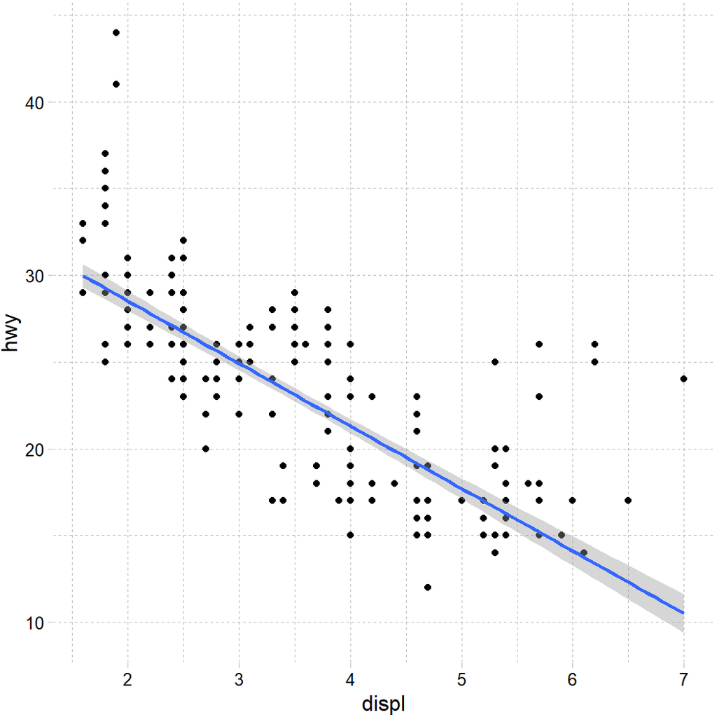

```r
library(MASS)
rlm_plot <- ggplot(mpg, aes(displ, hwy)) +
  geom_point() +
  geom_smooth(method = "rlm") +
  ggthemes::theme_pander()
rlm_plot
```

일반선형회귀모델의 결과와 로버스트 선형회귀모델의 결과를 나란히 보여주어 비교하기 편하게 할 수 있습니다. `patchwork` 패키지는 `ggplot`의 플롯들을 하나로 결합시켜주는 유용한 패키지입니다.

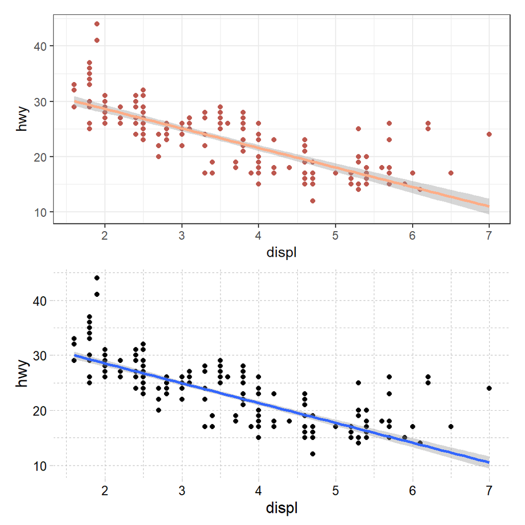

```r
# install.packages('devtools')
# devtools::install_github("thomasp85/patchwork")
library(patchwork)

lm_plot + rlm_plot + plot_layout(ncol = 1)
```

## 지터(Jitter) 플롯과 박스플롯

다시 데이터로 돌아와서, 만약에 우리가 자동차 구동방식에 따른 연료의 가성비에 관심이 있다고 해보겠습니다. 산포도를 그려볼 수 있겠죠?

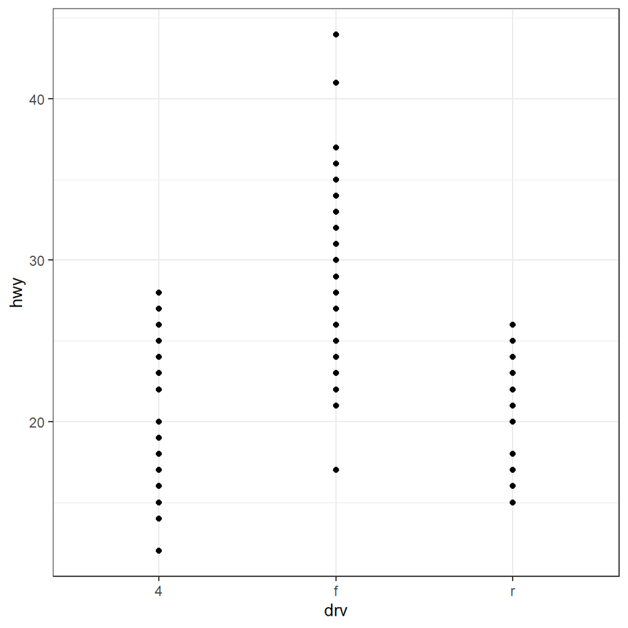

```r
ggplot(mpg, aes(drv, hwy)) +
  geom_point() + theme_bw()
```

뭐랄까, 그다지 정보를 파악하는 데 유용해보이지는 않습니다. 왜냐하면 저 점들이 하나의 관측치가 아니라 같은 값들을 가진 관측치들이 “겹쳐있기” 때문입니다. 관측치들의 집중도를 살펴보기 위해서는 투명도를 조정해주면 됩니다.

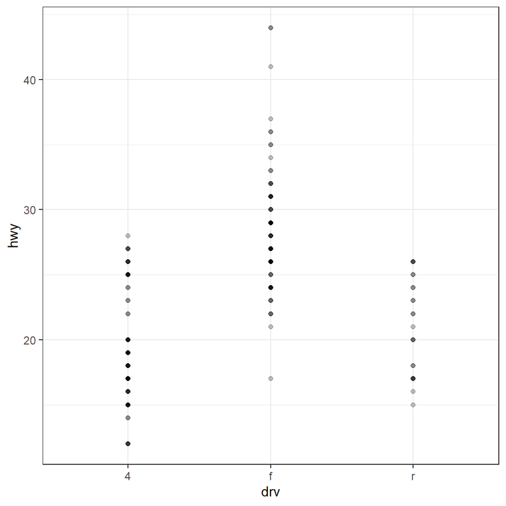

```r
ggplot(mpg, aes(drv, hwy)) +
  geom_point(alpha = .25) + theme_bw()
```

혹은 `hex`를 이용해 농도로 관측치들의 집중도를 나타내줄 수 있습니다.

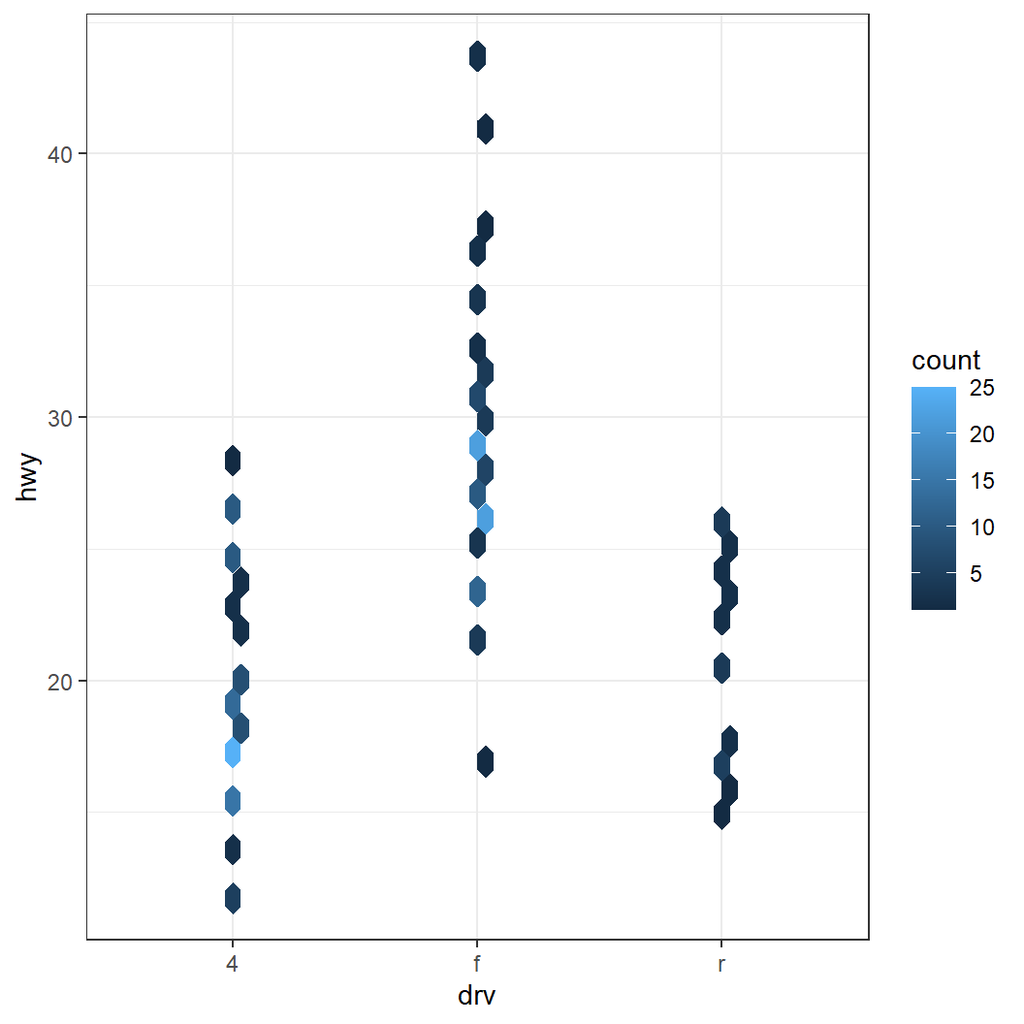

```r
ggplot(mpg, aes(drv, hwy)) +
  geom_hex() + theme_bw()
```

하지만 보다 일반적으로 사용되는 방법은 지터 플롯을 이용하는 것입니다. 지터 플롯은 무작위 노이즈를 값에 더해서 점들이 미묘하게 다른 값을 가지게 해 산포도를 알아보기 쉽게 “옆으로” 퍼트리는 것이라고 볼 수 있습니다.

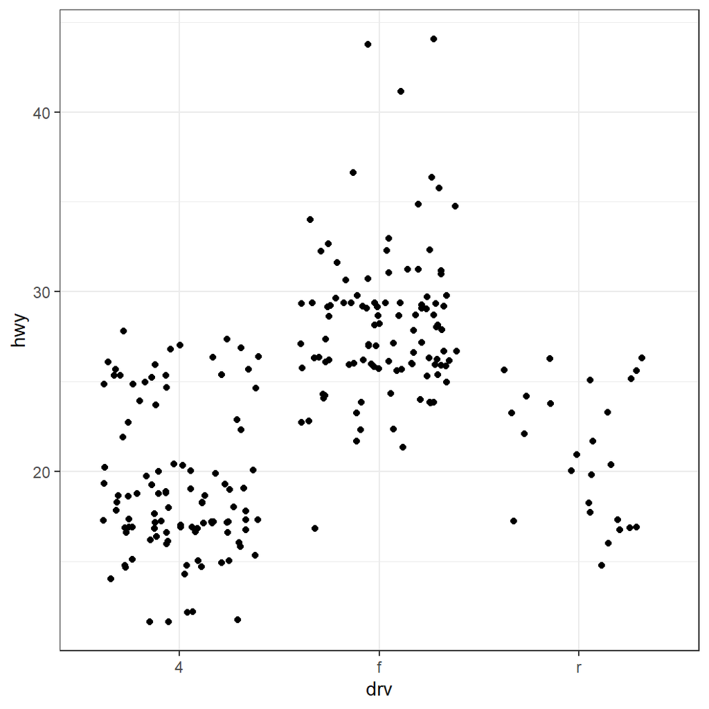

```r
ggplot(mpg, aes(drv, hwy)) +
  geom_jitter() + theme_bw()
```

자동차 구동방식에 따라 나타내고자 하였기 때문에 알아보기 쉽게 색을 더해보도록 하겠습니다.

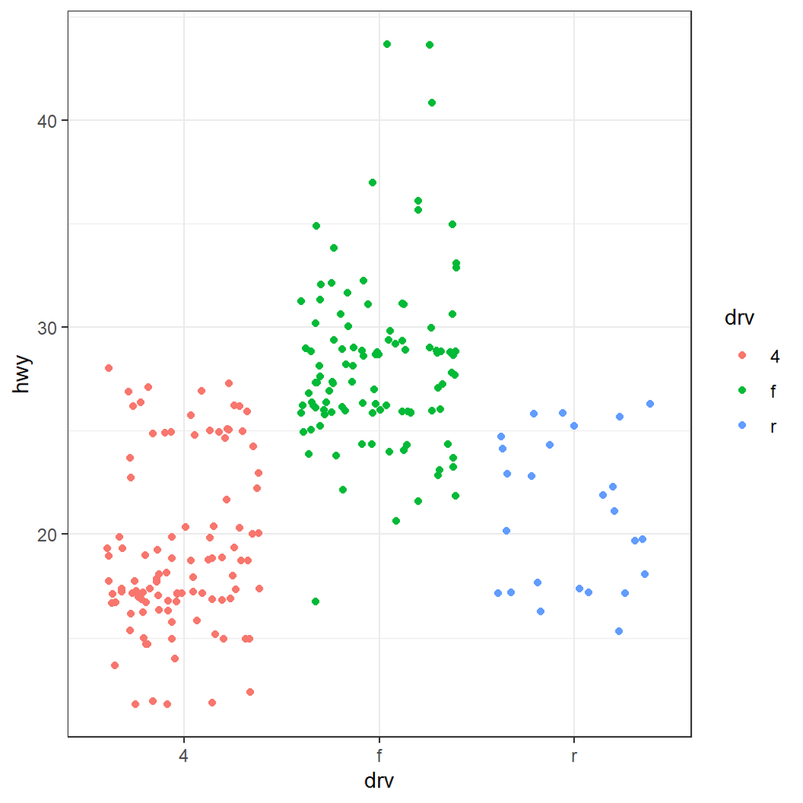

```r
ggplot(mpg, aes(drv, hwy, color = drv)) +
  geom_jitter() + theme_bw()
```

이와 유사한 정보를 주는 다른 종류의 플롯으로는 박스플롯과 바이올린 플롯이 있습니다. 참고로 박스플롯의 안에 그려진 선은 평균이 아니라 중앙값(median)입니다.

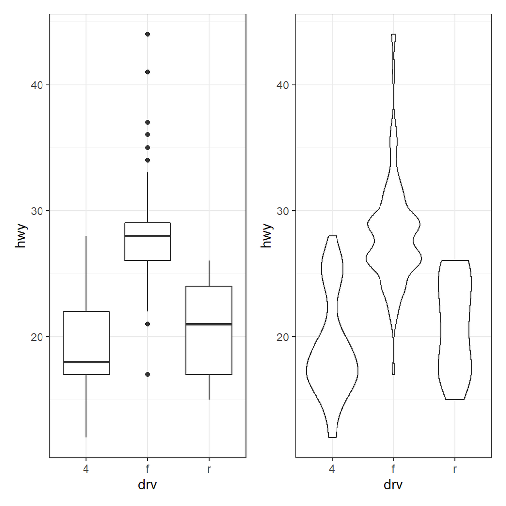

```r
box <- ggplot(mpg, aes(drv, hwy)) + geom_boxplot() + theme_bw()
violin <- ggplot(mpg, aes(drv, hwy)) + geom_violin() + theme_bw()
box + violin + plot_layout(ncol = 2)
```

히스토그램과 폴리곤 플롯도 어렵지 않게 `ggplot`으로 그릴 수 있습니다. 박스플롯이 서로 다른 두 변수 간의 관계를 보여주는 데 유용하다면, 히스토그램과 빈도폴리곤은 하나의 연속형 변수의 분포를 보여줄 때 사용합니다.

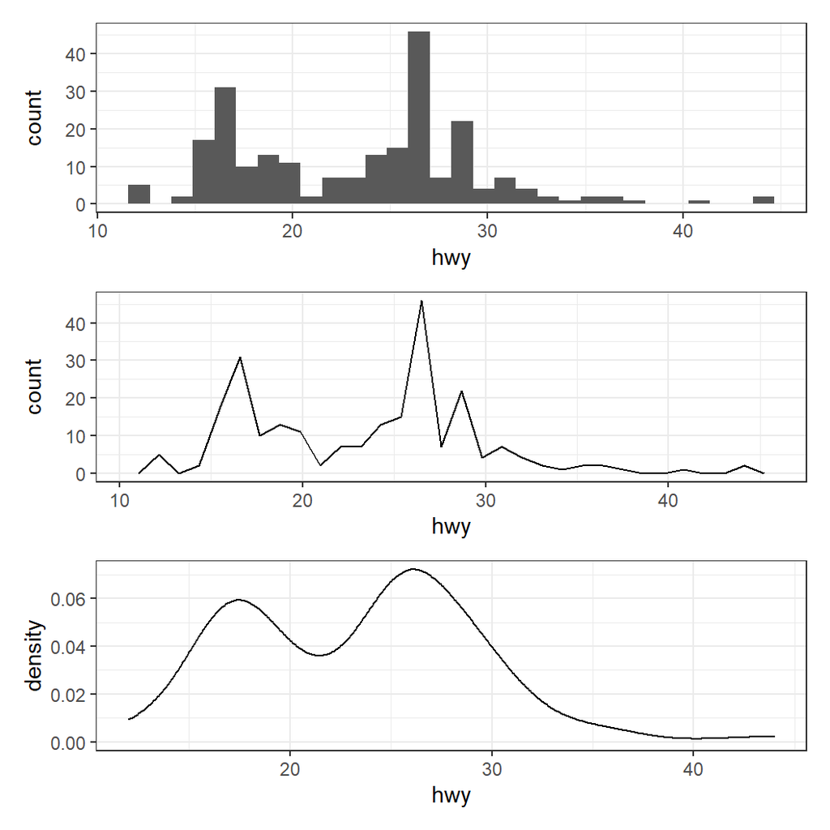

```r
hist <- ggplot(mpg, aes(hwy)) + geom_histogram() + theme_bw()
poly <- ggplot(mpg, aes(hwy)) + geom_freqpoly() + theme_bw()
dens <- ggplot(mpg, aes(hwy)) + geom_density() + theme_bw()
hist + poly + dens + plot_layout(ncol = 1)
```

만약 원한다면 구간(binning)을 특정해줄 수도 있습니다.

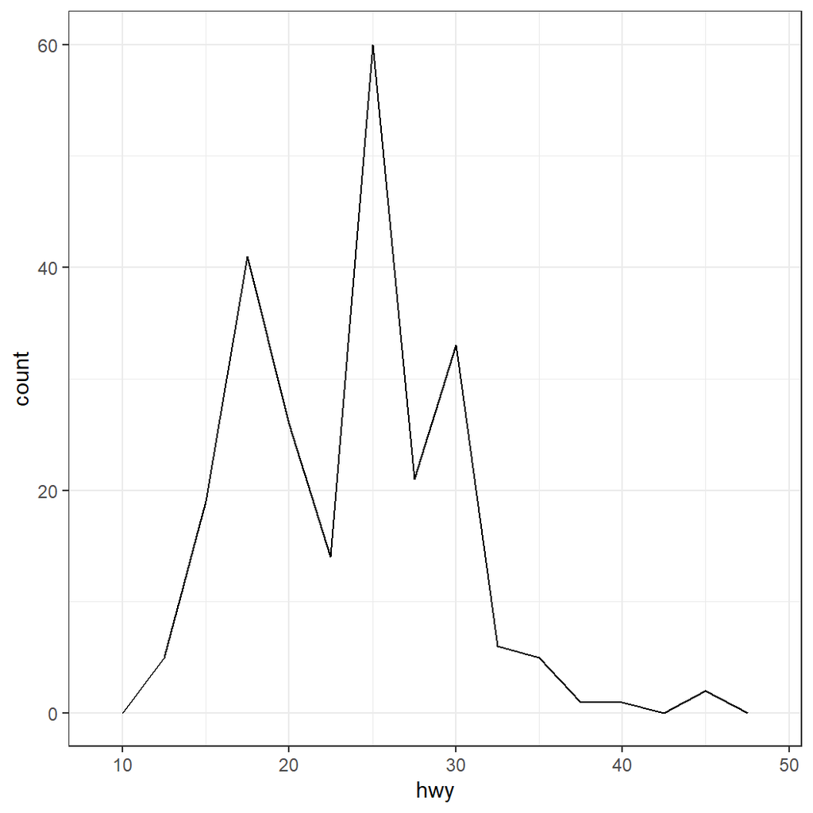

```r
ggplot(mpg, aes(hwy)) + geom_freqpoly(binwidth = 2.5) + theme_bw()
```

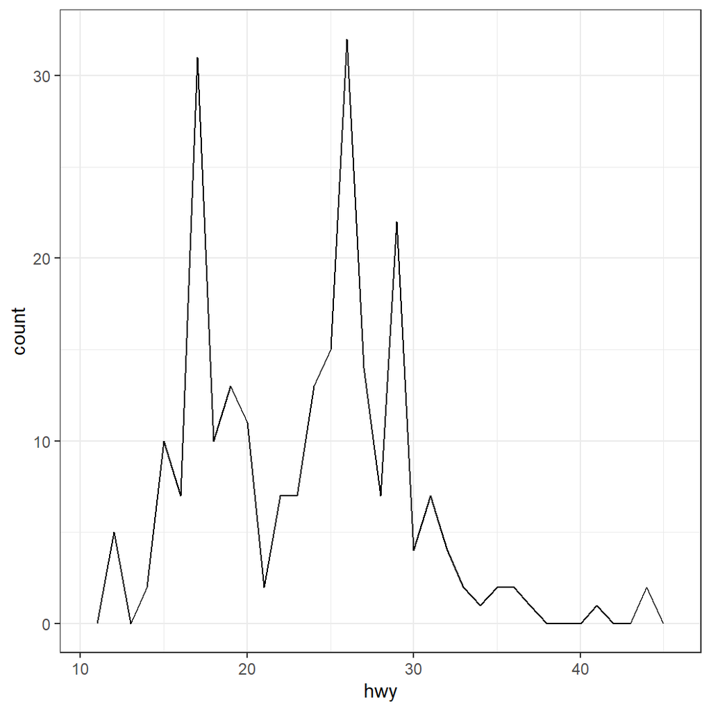

```r
ggplot(mpg, aes(hwy)) + geom_freqpoly(binwidth = 1) + theme_bw()
```

연속형 변수를 대상으로 `histogram` 등을 사용한다면, 이번에는 이산형 변수의 분포를 알아볼 때 유용한 막대플롯을 살펴보겠겠습니다. 당연히 `geom_bar()` 함수를 사용합니다.

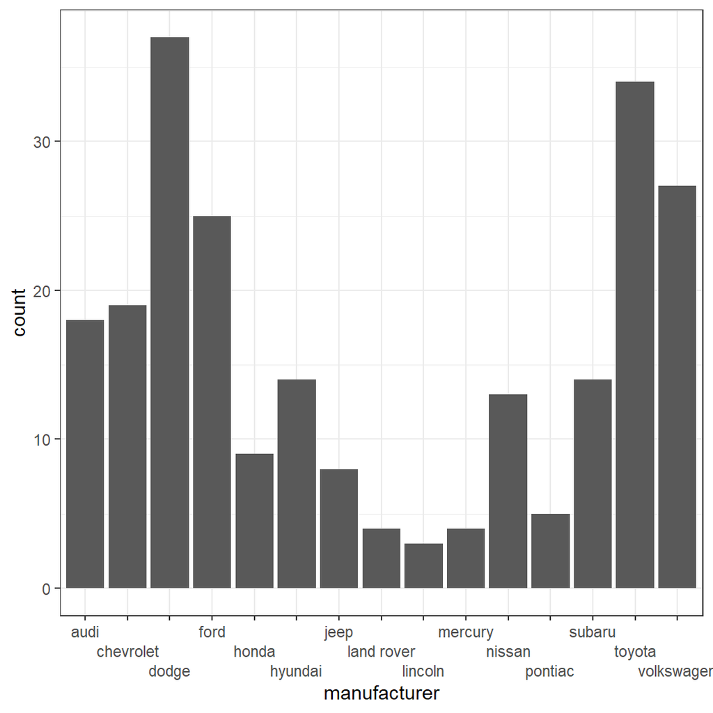

```r
ggplot(mpg, aes(manufacturer)) +
  geom_bar() +
  scale_x_discrete(guide = guide_axis(n.dodge=3))+
  theme_bw()
```

막대 플롯과 같은 경우, 우리가 가진 데이터를 요약해서 보여주지만, 요약된 자료 그 자체를 가지고 바로 막대플롯으로도 만들 수 있습니다. 예를 들어, 아래와 같은 데이터가 있다고 해보겠습니다.

```r
drugs <- data.frame(
  drug = c("a", "b", "c"),
  effect = c(4.2, 9.7, 6.1)
)
```

만약 이 경우, 우리는 `ggplot`에게 “이미 이 데이터는 요약된 정보를 가진 데이터야” 라는 것을 알려주기 위해 `stat = "identity"` 라는 특성을 제공합니다.

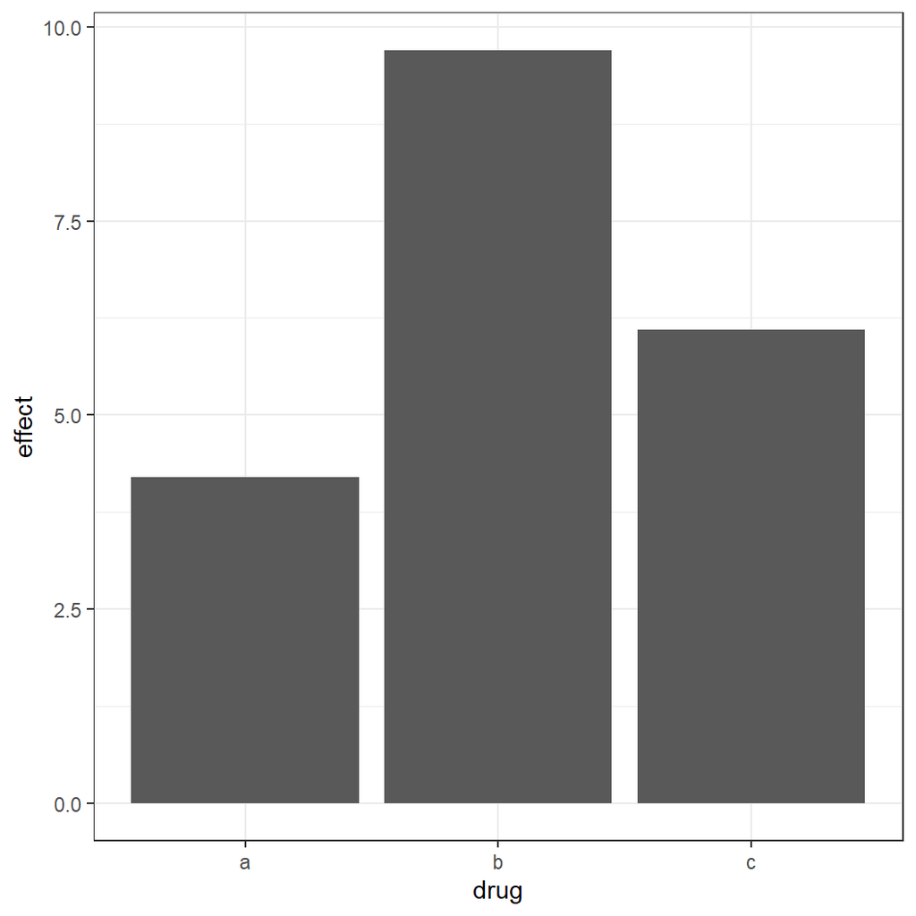

```r
ggplot(drugs, aes(drug, effect)) +
  geom_bar(stat = 'identity') + theme_bw()
```

막대 플롯을 그리는 데에는 `geom_col()`도 이용할 수 있습니다/

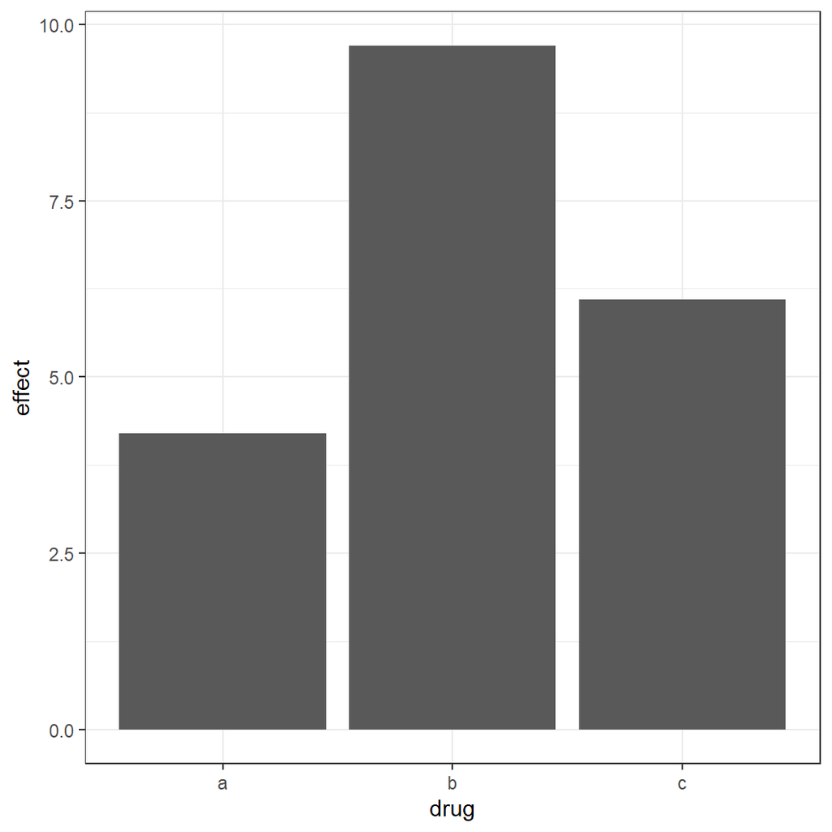

```r
ggplot(drugs, aes(drug, effect)) + geom_col() + theme_bw()
```

라인 플롯은 관측치—점들을 왼쪽에서 오른쪽으로 이어주는 플롯이고, 반대로 경로 플롯(path plot)은 데이터셋에 나타나는 순서대로 이어주는 플롯입니다. 즉, 라인 플롯은 `x`의 값대로 정렬된 형태의 경로 플롯이라고 이해하실 수 있습니다.

```r
temp_data <- tibble(
  x = sample(1:100, 25, replace = F),
  y = rnorm(25, 10, 2)
)
```

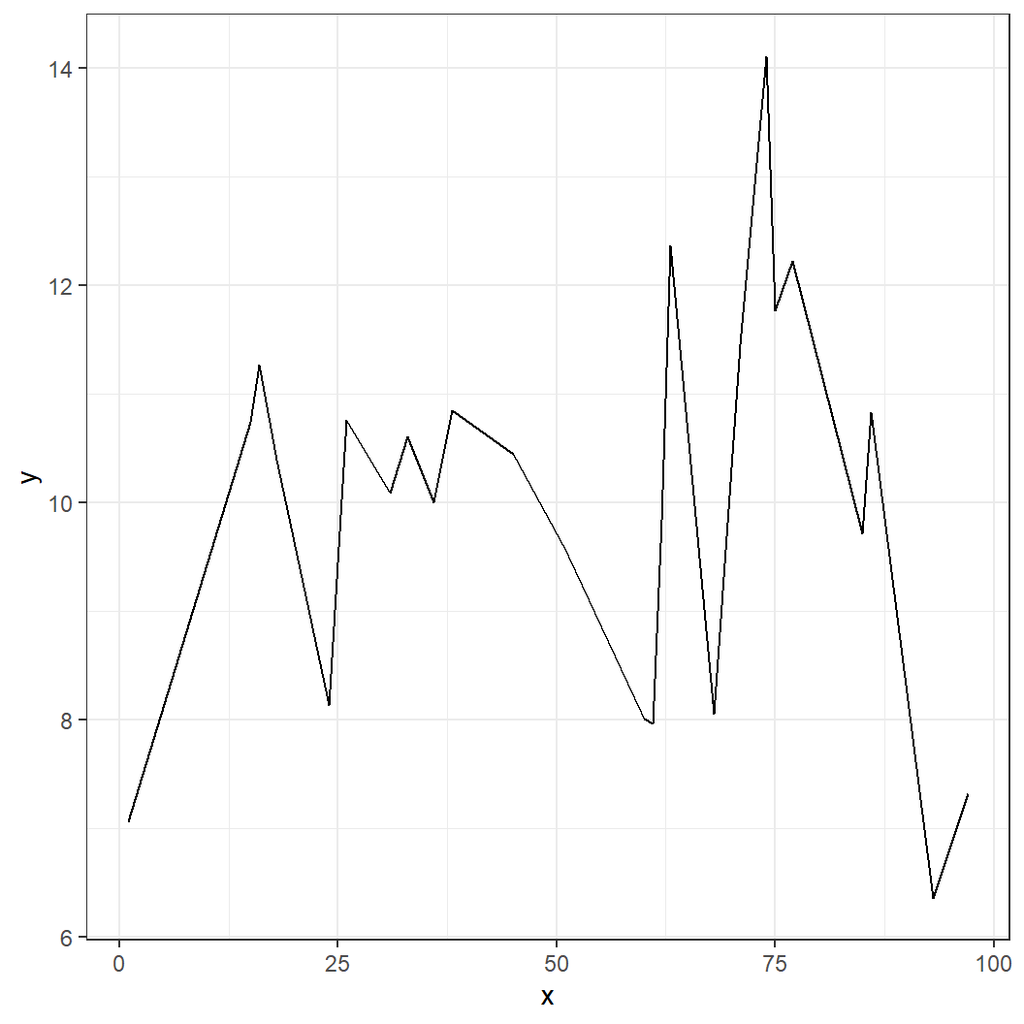

```r
## 라인 플롯입니다.
temp_data %>%
  ggplot(aes(x = x, y = y)) + geom_line() + theme_bw()
```

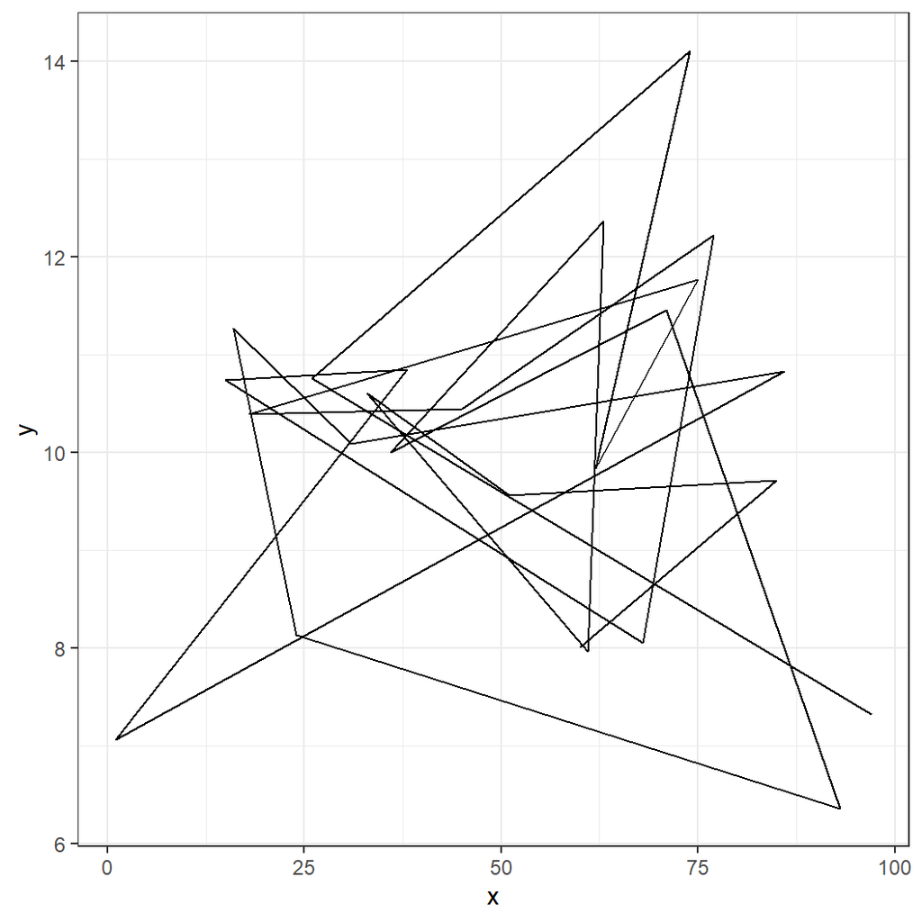

```r
## 경로 플롯입니다.
temp_data %>%
  ggplot(aes(x = x, y = y)) + geom_path() + theme_bw()
```

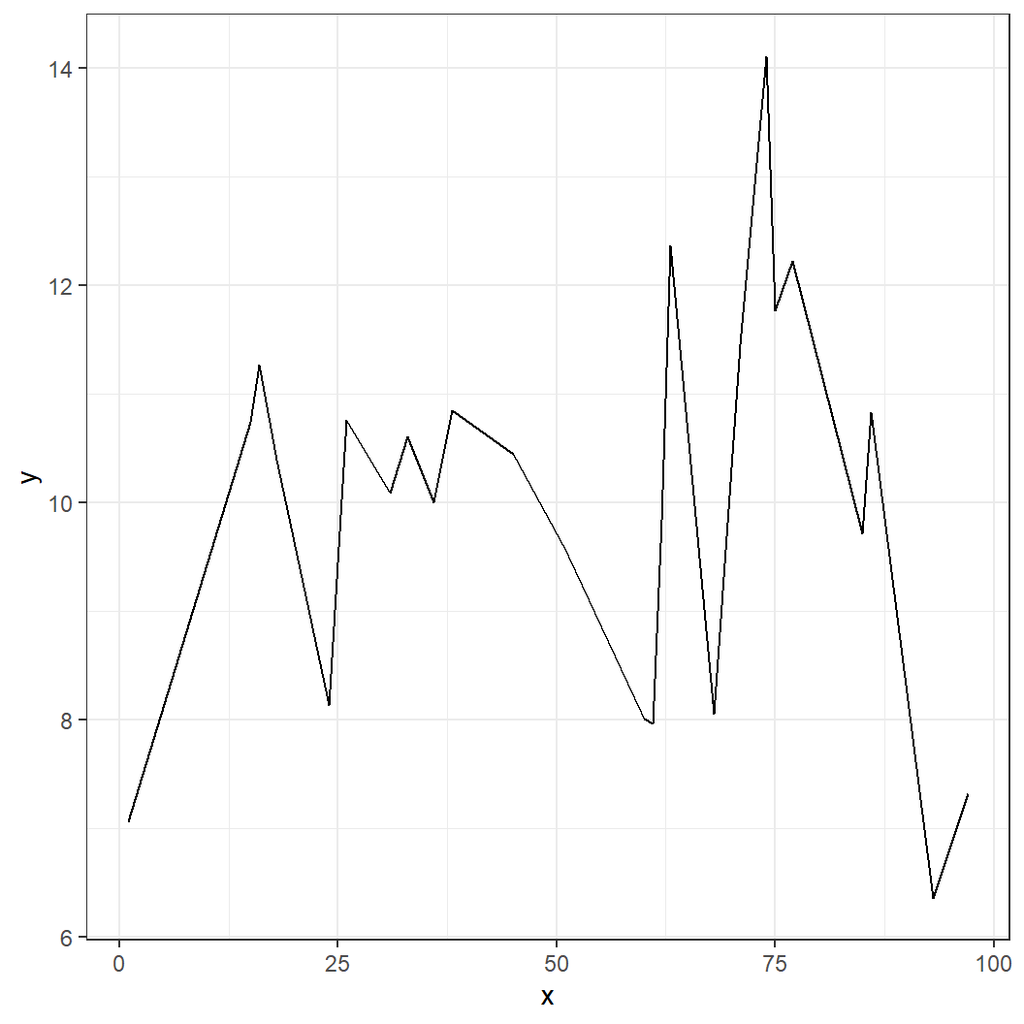

```r
## x 값을 정렬한 경로 플롯입니다.
temp_data %>%
  arrange(x) %>%
  ggplot(aes(x = x, y = y)) + geom_path() + theme_bw()
```

## 축 수정(Modifying Axes)

축의 제목을 수정하기 위해서는 각각의 축에 대해 `xlab()`, `ylab()`을 사용하거나 혹은 `labs()`를 이용해 한 번에 수정하는 방법이 있습니다.

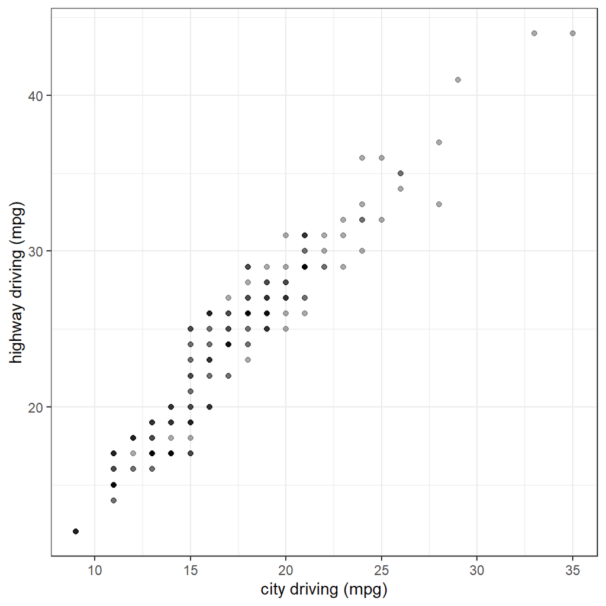

```r
ggplot(mpg, aes(cty, hwy)) +
  geom_point(alpha = 1 / 3) +
  xlab("city driving (mpg)") +
  ylab("highway driving (mpg)") +
  theme_bw()
```

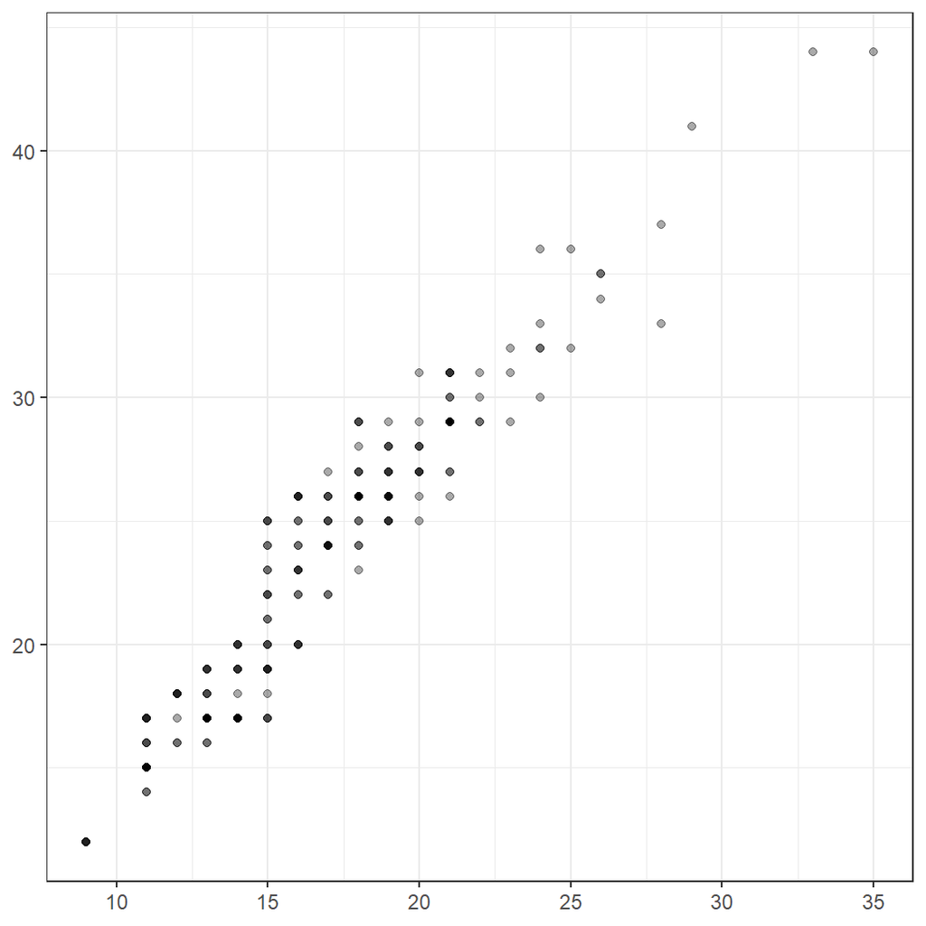

```r
# 축 제목을 모두 없애보겠습니다/
ggplot(mpg, aes(cty, hwy)) +
  geom_point(alpha = 1 / 3) +
  xlab(NULL) +
  ylab(NULL) +
  theme_bw()
```

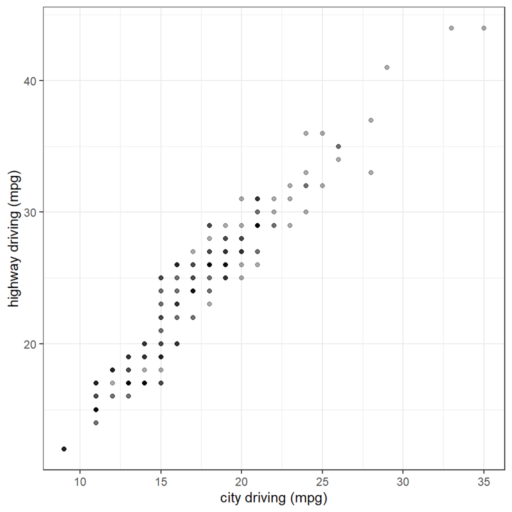

```r
# labs()를 이용해서 한 번에 간편하게 할 수도 있습니다.
ggplot(mpg, aes(cty, hwy)) +
  geom_point(alpha = 1 / 3) +
  labs(x = "city driving (mpg)", y = "highway driving (mpg)") +
  theme_bw()
```

각 축의 값의 범주를 조정할 수도 있습니다. 이때 필요한 함수들은 `xlim()`, `ylim()`, 그리고 `lims()` 입니다.

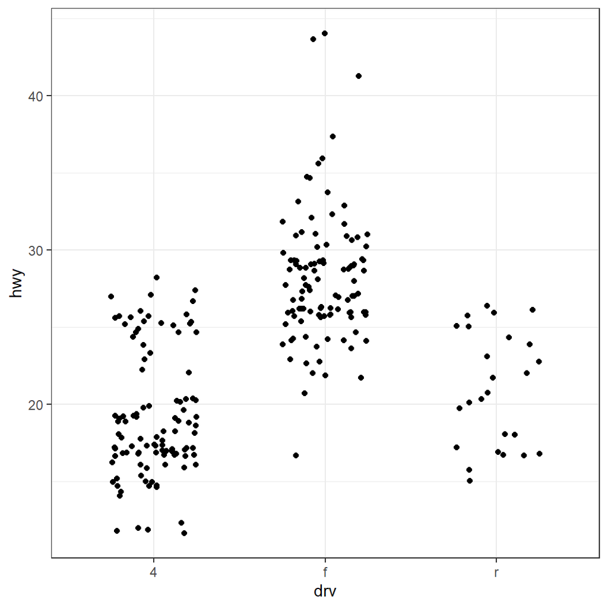

```r
ggplot(mpg, aes(drv, hwy)) +
  geom_jitter(width = 0.25) + theme_bw()
```